```r
options(OutDec = ".")  # Asegurar punto decimal en este chunk

# Establecer semilla aleatoria
# set.seed(sample(1:10000, 1))

# Función principal de generación de datos
generar_datos_completos <- function() {
  # Ternas pitagóricas expandidas para mayor diversidad
  ternas_pedagogicas <- list(
    c(3, 4, 5),     # Terna básica más conocida
    c(5, 12, 13),   # Segunda terna clásica
    c(8, 15, 17),   # Tercera terna clásica
    c(6, 8, 10),    # Múltiplo de (3,4,5)
    c(9, 12, 15),   # Múltiplo de (3,4,5)
    c(7, 24, 25),   # Cuarta terna clásica
    c(10, 24, 26),  # Múltiplo de (5,12,13)
    c(12, 16, 20),  # Múltiplo de (3,4,5)
    c(15, 20, 25),  # Múltiplo de (3,4,5)
    c(9, 40, 41),   # Quinta terna clásica
    c(11, 60, 61),  # Sexta terna clásica
    c(13, 84, 85),  # Séptima terna clásica
    c(16, 30, 34),  # Múltiplo de (8,15,17)
    c(20, 21, 29),  # Octava terna clásica
    c(18, 24, 30),  # Múltiplo de (3,4,5)
    c(21, 28, 35),  # Múltiplo de (3,4,5)
    c(24, 32, 40),  # Múltiplo de (3,4,5)
    c(27, 36, 45),  # Múltiplo de (3,4,5)
    c(30, 40, 50),  # Múltiplo de (3,4,5)
    c(33, 44, 55)   # Múltiplo de (3,4,5)
  )

  # Seleccionar terna aleatoriamente
  terna_seleccionada <- sample(ternas_pedagogicas, 1)[[1]]

  # Asignar valores manteniendo la relación pitagórica
  # La hipotenusa siempre debe ser el valor más grande
  valores_ordenados <- sort(terna_seleccionada)
  cateto_a <- valores_ordenados[1]
  cateto_b <- valores_ordenados[2]
  hipotenusa_c <- valores_ordenados[3]

  # Verificar que la terna cumple el teorema de Pitágoras
  if (cateto_a^2 + cateto_b^2 != hipotenusa_c^2) {
    # Si no cumple, usar la terna (3,4,5) como respaldo
    cateto_a <- 3
    cateto_b <- 4
    hipotenusa_c <- 5
  }

  # Validación final: asegurar que la terna es válida
  stopifnot(cateto_a^2 + cateto_b^2 == hipotenusa_c^2)
  stopifnot(hipotenusa_c > cateto_a && hipotenusa_c > cateto_b)

  # Contextos educativos variados con mayor diversidad
  contextos_educativos <- c(
    "construcción de una rampa de acceso",
    "diseño de una escalera",
    "cálculo de distancias en un plano cartesiano",
    "medición de la diagonal de un rectángulo",
    "navegación marítima entre dos puertos",
    "diseño de un tejado triangular",
    "cálculo de cables de tensión",
    "medición en topografía",
    "diseño de una piscina rectangular",
    "construcción de un puente",
    "cálculo de la altura de un edificio",
    "diseño de una cancha deportiva",
    "medición de terrenos agrícolas",
    "construcción de una torre de comunicación",
    "diseño de un parqueadero",
    "cálculo de distancias en arquitectura",
    "medición de superficies irregulares",
    "diseño de sistemas de riego",
    "construcción de vías de acceso",
    "cálculo de materiales de construcción"
  )

  contexto_seleccionado <- sample(contextos_educativos, 1)

  # Aleatorización de términos matemáticos
  terminos_cateto <- c("cateto", "lado", "base", "altura", "ancho", "largo")
  terminos_hipotenusa <- c("hipotenusa", "diagonal", "distancia", "longitud total", "medida principal")
  terminos_teorema <- c("Teorema de Pitágoras", "fórmula pitagórica", "ecuación pitagórica", "principio pitagórico")

  termino_cateto <- sample(terminos_cateto, 1)
  termino_hipotenusa <- sample(terminos_hipotenusa, 1)
  termino_teorema <- sample(terminos_teorema, 1)

  # Determinar el artículo correcto según el género del término
  if (termino_teorema %in% c("fórmula pitagórica", "ecuación pitagórica")) {
    articulo_teorema <- "la"
  } else {
    articulo_teorema <- "el"
  }

  # Generar datos para los 12 pasos progresivos
  datos_pasos <- list()

  # PASO 1: Identificación de elementos (schoice) - Aleatorización de opciones
  opciones_paso1 <- c(
    "dos catetos y una hipotenusa",
    "tres catetos",
    "una hipotenusa y dos ángulos agudos",
    "tres hipotenusas",
    "dos lados iguales y una base",
    "un ángulo recto y dos lados",
    "tres ángulos agudos",
    "dos hipotenusas y un cateto"
  )
  # Asegurar que la opción correcta esté incluida
  opcion_correcta_paso1 <- "dos catetos y una hipotenusa"
  opciones_incorrectas_paso1 <- opciones_paso1[opciones_paso1 != opcion_correcta_paso1]
  opciones_seleccionadas_paso1 <- c(opcion_correcta_paso1, sample(opciones_incorrectas_paso1, 3))
  opciones_paso1_mezcladas <- sample(opciones_seleccionadas_paso1, 4)
  indice_correcto_paso1 <- which(opciones_paso1_mezcladas == opcion_correcta_paso1)[1]

  datos_pasos$paso1 <- list(
    pregunta = "¿Cuáles son los elementos principales de un triángulo rectángulo?",
    opciones = opciones_paso1_mezcladas,
    correcta = indice_correcto_paso1,
    tipo = "schoice"
  )

  # PASO 2: Reconocimiento del teorema (mchoice) - Aleatorización de opciones
  opciones_paso2 <- c(
    "Se aplica solo a triángulos rectángulos",
    "La hipotenusa es el lado más largo",
    "Se puede escribir como a² + b² = c²",
    "Se aplica a cualquier triángulo",
    "Los catetos son siempre iguales",
    "La suma de los ángulos es 180°",
    "Se puede usar para calcular áreas",
    "Solo funciona con números enteros"
  )
  # Asegurar inclusión de al menos una opción correcta
  correctas_texto_paso2 <- c(
    "Se aplica solo a triángulos rectángulos",
    "La hipotenusa es el lado más largo",
    "Se puede escribir como a² + b² = c²"
  )
  incorrectas_texto_paso2 <- setdiff(opciones_paso2, correctas_texto_paso2)
  seleccion_paso2 <- c(sample(correctas_texto_paso2, 2), sample(incorrectas_texto_paso2, 2))
  opciones_paso2_mezcladas <- sample(seleccion_paso2, 4)
  correctas_paso2 <- opciones_paso2_mezcladas %in% correctas_texto_paso2

  datos_pasos$paso2 <- list(
    pregunta = paste("¿Cuáles de las siguientes afirmaciones sobre el", termino_teorema, "son correctas?"),
    opciones = opciones_paso2_mezcladas,
    correctas = correctas_paso2,
    tipo = "mchoice"
  )

  # PASO 3: Identificación de la hipotenusa (schoice) - Aleatorización de opciones
  opciones_paso3 <- c(
    as.character(cateto_a),
    as.character(cateto_b),
    as.character(hipotenusa_c),
    "No se puede determinar",
    as.character(cateto_a + cateto_b),
    as.character(abs(cateto_a - cateto_b)),
    as.character(cateto_a * cateto_b),
    as.character(hipotenusa_c + 1)
  )
  # Asegurar inclusión de la opción correcta (hipotenusa)
  opcion_correcta_paso3 <- as.character(hipotenusa_c)
  opciones_incorrectas_paso3 <- setdiff(opciones_paso3, opcion_correcta_paso3)
  opciones_seleccionadas_paso3 <- c(opcion_correcta_paso3, sample(opciones_incorrectas_paso3, 3))
  opciones_paso3_mezcladas <- sample(opciones_seleccionadas_paso3, 4)
  indice_correcto_paso3 <- which(opciones_paso3_mezcladas == opcion_correcta_paso3)[1]
```

```r
  datos_pasos$paso3 <- list(
    pregunta = paste("En el triángulo con lados", cateto_a, ",", cateto_b, "y", hipotenusa_c, ", ¿cuál es la", termino_hipotenusa, "?"),
    opciones = opciones_paso3_mezcladas,
    correcta = indice_correcto_paso3,
    tipo = "schoice"
  )

  # PASO 4: Cálculo de cuadrados (num)
  datos_pasos$paso4 <- list(
    pregunta = paste("Calcula", cateto_a, "²:"),
    respuesta = cateto_a^2,
    tipo = "num",
    tolerancia = 0
  )

  # PASO 5: Cálculo de cuadrados (num)
  datos_pasos$paso5 <- list(
    pregunta = paste("Calcula", cateto_b, "²:"),
    respuesta = cateto_b^2,
    tipo = "num",
    tolerancia = 0
  )

  # PASO 6: Suma de cuadrados (num)
  datos_pasos$paso6 <- list(
    pregunta = paste("Calcula", cateto_a, "² +", cateto_b, "²:"),
    respuesta = cateto_a^2 + cateto_b^2,
    tipo = "num",
    tolerancia = 0
  )

  # PASO 7: Verificación del teorema (schoice) - Aleatorización de opciones
  opciones_paso7 <- c(
    "Sí",
    "No",
    "No se puede determinar",
    "Depende del contexto",
    "Solo si los catetos son iguales",
    "Solo con números enteros",
    "Solo en triángulos equiláteros",
    "Solo si la hipotenusa es par"
  )
  # Asegurar inclusión de la opción correcta ("Sí")
  opcion_correcta_paso7 <- "Sí"
  opciones_incorrectas_paso7 <- setdiff(opciones_paso7, opcion_correcta_paso7)
  opciones_seleccionadas_paso7 <- c(opcion_correcta_paso7, sample(opciones_incorrectas_paso7, 3))
  opciones_paso7_mezcladas <- sample(opciones_seleccionadas_paso7, 4)
  indice_correcto_paso7 <- which(opciones_paso7_mezcladas == opcion_correcta_paso7)[1]

  datos_pasos$paso7 <- list(
    pregunta = paste("¿Es cierto que", cateto_a, "² +", cateto_b, "² =", hipotenusa_c, "²?"),
    opciones = opciones_paso7_mezcladas,
    correcta = indice_correcto_paso7,
    tipo = "schoice"
  )

  # PASO 8: Aplicación inversa - encontrar cateto (num)
  # Crear un problema donde se conoce un cateto y la hipotenusa
  cateto_conocido <- cateto_a
  cateto_desconocido <- cateto_b
  datos_pasos$paso8 <- list(
    pregunta = paste("Si un cateto mide", cateto_conocido, "y la hipotenusa mide", hipotenusa_c, ", ¿cuánto mide el otro cateto?"),
    respuesta = cateto_desconocido,
    tipo = "num",
    tolerancia = 0.01
  )

  # PASO 9: Verificación de cálculo (schoice) - Aleatorización de opciones
  opciones_paso9 <- c(
    paste("Calcular √(", hipotenusa_c, "² -", cateto_conocido, "²)"),
    paste("Calcular", hipotenusa_c, "+", cateto_conocido),
    paste("Calcular", hipotenusa_c, "×", cateto_conocido),
    paste("Calcular", hipotenusa_c, "÷", cateto_conocido),
    paste("Calcular", hipotenusa_c, "² +", cateto_conocido, "²"),
    paste("Calcular √(", hipotenusa_c, "² +", cateto_conocido, "²)"),
    paste("Calcular", hipotenusa_c, "-", cateto_conocido),
    paste("Calcular √(", hipotenusa_c, "×", cateto_conocido, ")")
  )
  # Asegurar inclusión de la opción correcta (raíz con resta de cuadrados)
  opcion_correcta_paso9 <- paste("Calcular √(", hipotenusa_c, "² -", cateto_conocido, "²)")
  opciones_incorrectas_paso9 <- setdiff(opciones_paso9, opcion_correcta_paso9)
  opciones_seleccionadas_paso9 <- c(opcion_correcta_paso9, sample(opciones_incorrectas_paso9, 3))
  opciones_paso9_mezcladas <- sample(opciones_seleccionadas_paso9, 4)
  indice_correcto_paso9 <- which(opciones_paso9_mezcladas == opcion_correcta_paso9)[1]

  datos_pasos$paso9 <- list(
    pregunta = paste("Para verificar que", cateto_desconocido, "es correcto, ¿qué operación debemos realizar?"),
    opciones = opciones_paso9_mezcladas,
    correcta = indice_correcto_paso9,
    tipo = "schoice"
  )

  # PASO 10: Aplicación contextual (mchoice) - Aleatorización de opciones
  opciones_paso10 <- c(
    "Calcular distancias directas",
    "Determinar ángulos rectos",
    "Verificar medidas",
    "Calcular áreas de círculos",
    "Calcular perímetros de rectángulos",
    "Determinar volúmenes de cilindros",
    "Calcular superficies de esferas",
    "Verificar proporciones",
    "Calcular diagonales de cuadrados",
    "Determinar alturas de triángulos"
  )
  # Asegurar inclusión de al menos una opción correcta
  correctas_texto_paso10 <- c(
    "Calcular distancias directas",
    "Determinar ángulos rectos",
    "Verificar medidas",
    "Calcular diagonales de cuadrados",
    "Determinar alturas de triángulos"
  )
  incorrectas_texto_paso10 <- setdiff(opciones_paso10, correctas_texto_paso10)
  seleccion_paso10 <- c(sample(correctas_texto_paso10, 2), sample(incorrectas_texto_paso10, 2))
  opciones_paso10_mezcladas <- sample(seleccion_paso10, 4)
  correctas_paso10 <- opciones_paso10_mezcladas %in% correctas_texto_paso10

  datos_pasos$paso10 <- list(
    pregunta = paste("En el contexto de", contexto_seleccionado, ", ¿cuáles son aplicaciones válidas del", termino_teorema, "?"),
    opciones = opciones_paso10_mezcladas,
    correctas = correctas_paso10,
    tipo = "mchoice"
  )

  # PASO 11: Análisis de error común (schoice) - Aleatorización de opciones
  error_comun <- cateto_a + cateto_b  # Error: suma en lugar de teorema
  opciones_paso11 <- c(
    "Sumó los catetos en lugar de usar el teorema",
    "No calculó correctamente la suma",
    "Usó la fórmula incorrecta del área",
    "No hay error en el cálculo",
    "Confundió la hipotenusa con el perímetro",
    "Aplicó mal la fórmula de la raíz cuadrada",
    "No consideró que es un triángulo rectángulo",
    "Usó la fórmula del teorema de Tales"
  )
  # Asegurar inclusión de la opción correcta (error de suma de catetos)
  opcion_correcta_paso11 <- "Sumó los catetos en lugar de usar el teorema"
  opciones_incorrectas_paso11 <- setdiff(opciones_paso11, opcion_correcta_paso11)
  opciones_seleccionadas_paso11 <- c(opcion_correcta_paso11, sample(opciones_incorrectas_paso11, 3))
  opciones_paso11_mezcladas <- sample(opciones_seleccionadas_paso11, 4)
  indice_correcto_paso11 <- which(opciones_paso11_mezcladas == opcion_correcta_paso11)[1]

  datos_pasos$paso11 <- list(
    pregunta = paste("Un estudiante calcula la", termino_hipotenusa, "como", cateto_a, "+", cateto_b, "=", error_comun, ". ¿Cuál es el error?"),
    opciones = opciones_paso11_mezcladas,
    correcta = indice_correcto_paso11,
    tipo = "schoice"
  )
```

```r
  # PASO 12: Síntesis y transferencia (num)
  # Problema de transferencia con nueva terna
  nueva_terna <- sample(list(c(9, 12, 15), c(12, 16, 20), c(15, 20, 25)), 1)[[1]]
  nuevo_cateto_a <- nueva_terna[1]
  nuevo_cateto_b <- nueva_terna[2]
  nueva_hipotenusa <- nueva_terna[3]

  datos_pasos$paso12 <- list(
    pregunta = paste("Problema de transferencia: Si los catetos de un triángulo rectángulo miden", nuevo_cateto_a, "y", nuevo_cateto_b, ", ¿cuál es la longitud de la hipotenusa?"),
    respuesta = nueva_hipotenusa,
    tipo = "num",
    tolerancia = 0.01
  )

  return(list(
    cateto_a = cateto_a,
    cateto_b = cateto_b,
    hipotenusa_c = hipotenusa_c,
    contexto = contexto_seleccionado,
    termino_cateto = termino_cateto,
    termino_hipotenusa = termino_hipotenusa,
    termino_teorema = termino_teorema,
    articulo_teorema = articulo_teorema,
    pasos = datos_pasos
  ))
}

# Generar datos del ejercicio dinámicamente para cada versión
datos <- generar_datos_completos()

# Validaciones de coherencia matemática
test_that("Validación del Teorema de Pitágoras", {
  # Verificar que la terna seleccionada cumple el teorema
  expect_equal(datos$cateto_a^2 + datos$cateto_b^2, datos$hipotenusa_c^2)
})
```

Test passed 😀

```r
test_that("Validación de valores positivos", {
  expect_true(datos$cateto_a > 0)
  expect_true(datos$cateto_b > 0)
  expect_true(datos$hipotenusa_c > 0)
})
```

Test passed 😸

```r
test_that("Validación de la hipotenusa como lado más largo", {
  expect_true(datos$hipotenusa_c > datos$cateto_a)
  expect_true(datos$hipotenusa_c > datos$cateto_b)
})
```

Test passed 😸

```r
test_that("Validación de respuestas numéricas", {
  expect_equal(datos$pasos$paso4$respuesta, datos$cateto_a^2)
  expect_equal(datos$pasos$paso5$respuesta, datos$cateto_b^2)
  expect_equal(datos$pasos$paso6$respuesta, datos$cateto_a^2 + datos$cateto_b^2)
})
```

Test passed 🥇

# Question

## 🎯 **Entrenamiento Completo: fórmula pitagórica**

**Contexto:** En el ámbito de navegación marítima entre dos puertos, necesitas aplicar la fórmula pitagórica de manera sistemática y comprensiva.

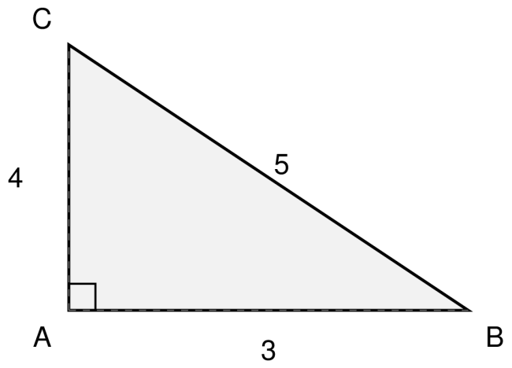

Completa los siguientes **12 pasos progresivos** para demostrar tu comprensión completa del Teorema de Pitágoras:

### **📚 FASE I: Comprensión Conceptual**

**Paso 1.** ¿Cuáles son los elementos principales de un triángulo rectángulo? ##ANSWER1##

**Paso 2.** ¿Cuáles de las siguientes afirmaciones sobre el fórmula pitagórica son correctas? ##ANSWER2##

**Paso 3.** En el triángulo con lados 3 , 4 y 5 , ¿cuál es la medida principal ? ##ANSWER3##

### **🔢 FASE II: Aplicación Numérica**

**Paso 4.** Calcula 3 ²: ##ANSWER4##

**Paso 5.** Calcula 4 ²: ##ANSWER5##

**Paso 6.** Calcula 3 ² + 4 ²: ##ANSWER6##

### **✅ FASE III: Verificación y Análisis**

**Paso 7.** ¿Es cierto que 3 ² + 4 ² = 5 ²? ##ANSWER7##

**Paso 8.** Si un cateto mide 3 y la hipotenusa mide 5 , ¿cuánto mide el otro cateto? ##ANSWER8##

**Paso 9.** Para verificar que 4 es correcto, ¿qué operación debemos realizar? ##ANSWER9##

### **🌍 FASE IV: Transferencia y Síntesis**

**Paso 10.** En el contexto de navegación marítima entre dos puertos , ¿cuáles son aplicaciones válidas del fórmula pitagórica ? ##ANSWER10##

**Paso 11.** Un estudiante calcula la medida principal como 3 + 4 = 7 . ¿Cuál es el error? ##ANSWER11##

**Paso 12.** Problema de transferencia: Si los catetos de un triángulo rectángulo miden 9 y 12 , ¿cuál es la longitud de la hipotenusa? ##ANSWER12##

## Answerlist

- dos lados iguales y una base
- una hipotenusa y dos ángulos agudos
- tres ángulos agudos
- dos catetos y una hipotenusa
- Se puede escribir como a² + b² = c²
- La suma de los ángulos es 180°
- Se aplica solo a triángulos rectángulos
- Los catetos son siempre iguales
- 1
- No se puede determinar
- 5
- 12
- Solo si la hipotenusa es par
- Solo si los catetos son iguales
- No se puede determinar
- Sí
- Calcular √( 5 × 3 )
- Calcular √( 5 ² - 3 ²)
- Calcular 5 ² + 3 ²
- Calcular 5 - 3
- Verificar medidas
- Calcular superficies de esferas
- Calcular distancias directas
- Calcular áreas de círculos
- No calculó correctamente la suma
- Aplicó mal la fórmula de la raíz cuadrada
- Sumó los catetos en lugar de usar el teorema
- Usó la fórmula incorrecta del área

# Solution

## 🎯 **Solución Completa del Entrenamiento: fórmula pitagórica**

Este ejercicio pedagógico evalúa la comprensión integral de la fórmula pitagórica a través de 12 pasos progresivos que abarcan desde conceptos básicos hasta aplicaciones avanzadas.

### **📚 FASE I: Comprensión Conceptual**

**Paso 3:** En el triángulo con lados 3, 4 y 5, la hipotenusa es **5** porque es el lado más largo.

### **🔢 FASE II: Aplicación Numérica**

**Paso 4:** 3² = **9**

**Paso 5:** 4² = **16**

**Paso 6:** 3² + 4² = 9 + 16 = **25**

### **✅ FASE III: Verificación y Análisis**

**Paso 7:** **Sí**, es cierto que 3² + 4² = 5² porque 25 = 25.

**Paso 8:** Si un cateto mide 3 y la hipotenusa mide 5, el otro cateto mide **4**. Cálculo: √(5² - 3²) = √(25 - 9) = √16 = 4

**Paso 9:** Para verificar que 4 es correcto, debemos **calcular √(5² - 3²)**, que es la aplicación directa de la fórmula pitagórica despejando un cateto.

### **🌍 FASE IV: Transferencia y Síntesis**

**Paso 11:** El error del estudiante es que **sumó los catetos en lugar de usar la fórmula pitagórica**. La suma 3 + 4 = 7 no da la hipotenusa correcta (5).

### **📋 Explicaciones Detalladas por Paso**

**Paso 1:** Respuesta correcta: dos catetos y una hipotenusa

**Paso 2:** Respuestas correctas: Se puede escribir como a² + b² = c², Se aplica solo a triángulos rectángulos

**Paso 3:** Respuesta correcta: 5

**Paso 4:** Respuesta numérica: 9

**Paso 5:** Respuesta numérica: 16

**Paso 6:** Respuesta numérica: 25

**Paso 7:** Respuesta correcta: Sí

**Paso 8:** Respuesta numérica: 4

**Paso 9:** Respuesta correcta: Calcular √( 5 ² - 3 ²)

**Paso 10:** Respuestas correctas: Verificar medidas, Calcular distancias directas

**Paso 11:** Respuesta correcta: Sumó los catetos en lugar de usar el teorema

**Paso 12:** Respuesta numérica: 15

### **🎓 Evaluación Pedagógica**

Este ejercicio evalúa:

- **Comprensión conceptual** (Pasos 1-3): Identificación de elementos y principios
- **Habilidades de cálculo** (Pasos 4-6): Operaciones aritméticas básicas
- **Aplicación del teorema** (Pasos 7-9): Uso directo e inverso de la fórmula
- **Transferencia de conocimiento** (Pasos 10-12): Aplicación a nuevos contextos

La progresión de dificultad asegura que los estudiantes desarrollen una comprensión profunda y duradera de la fórmula pitagórica, previniendo respuestas mecánicas y promoviendo el razonamiento matemático.

# Meta-information

exname: teorema_pitagoras_entrenamiento_completo_cloze_geometrico_metrico_formulacion_ejecucion_n2 extype: cloze exsolution: 0001|1010|0010|9|16|25|0001|4|0100|1010|0010|15 exclozetype: schoice|mchoice|schoice|num|num|num|schoice|num|schoice|mchoice|schoice|num extol: 0|0|0|0|0|0|0|0.01|0|0|0|0.01 exshuffle: TRUE exsection: Geometria|Teorema de Pitagoras|Entrenamiento Completo exversion: 1 exdate: 2025-09-28 exauthor: Sistema de Generacion ICFES exemail: alvaroangelm@iepedacitodecielo.edu.co exinstitution: ICFES exlanguage: es excomment: Ejercicio de entrenamiento completo del Teorema de Pitagoras con 12 pasos progresivos que incluyen comprension conceptual, aplicacion numerica, verificacion y transferencia de conocimiento. Optimizado para generar mas de 300 variantes unicas con aleatorizacion avanzada de contextos, terminos matematicos y opciones de respuesta.

## METADATOS ICFES 2025 OBLIGATORIOS

icfes: competencia: formulacion_ejecucion nivel_dificultad: 2 contenido: categoria: geometria tipo: generico contexto: matematico eje_axial: eje2 componente: geometrico_metrico afirmacion: Utiliza representaciones geometricas y propiedades de figuras geometricas para resolver problemas de medicion evidencia: Resuelve problemas que requieren el uso del teorema de Pitagoras dificultad_estimada: media tiempo_estimado_minutos: 15 requiere_calculadora: false tipo_pregunta_icfes: cloze_entrenamiento palabras_clave: [teorema_pitagoras, triangulo_rectangulo, catetos, hipotenusa, geometria_euclidiana]